# Craft Beer

Alcohol Content and Bitterness Preference Analysis

October 20, 2018

```r
knitr::opts_chunk$set(echo = FALSE)
#Prepared by Michael Catalano + Hayley Horn
#6306-404 Case Study #1
```

```r
#These are the packages used in this project.
library(blogdown)
library(data.table)
library(DT)
library(ggplot2)
library(kableExtra)
library(plyr)
library(RColorBrewer)
```

Beer can be made using a range of ingredients to adjust the color, type and flavor profile. This analysis focuses on two measurements of beer composition, and some geographic details. The first measurement is Alcohol By Volume (ABV) which is a percentage that represents how much of a beer is alcohol versus other ingredients. The other measurment we will consider is International Business Units (IBU) which is measured on a scale of 0 to 100 and describes the bitterness from hops in a beer. By law in the United States, the ABV must be listed on each beer to give customers an idea about how much alcohol is in each brew.

For this analysis, we have taken data from 2,410 craft beers and sales data from 558 US breweries to identify trends or regionality for preference. We use craft brewery data versus national brands as there is more product experimentation and product churn.

**There is a great amount of variablility in number of breweries by state.**  
Colorado leads the country with 47 breweries, and there are 4 states that have exactly 1 at the time of the study. Use the slider functionality if you need a specific range of values for number of breweries within a state.

| State | Brew_Count |
| --- | --- |
| AK | 7 |
| AL | 3 |
| AR | 2 |
| AZ | 11 |
| CA | 39 |
| CO | 47 |
| CT | 8 |
| DC | 1 |
| DE | 2 |
| FL | 15 |

[output cut: 41 more lines]

**First we take a look at the first and last 6 records of the beer and brewery data**  
We merged the data from both files for a consolidated view of brewery information, beer information, including the ingredients of interest ABV and IBU and other attributes were pulled in to for some flexibility in analysis. The top of the file looks fairly complete and clean.

The end of the file indicates there are IBU values missing, so next we look to see the extent to which the field is incomplete.

```r
#2. Merge beer data with the breweries data. Print the first six observations and last six observations to check the merged file.

BandBs <- (merge(Beer,Brew, by = "Brew_ID")) #This small bit of code merges the data sets.

kable(head(BandBs,6), longtable = TRUE, booktabs=TRUE, caption="The first 6 records in the Beer and Brewery file") %>% kable_styling(full_width = FALSE) #This line prints the first 6 lines of the Beer merged beer & brewery data.
```

The first 6 records in the Beer and Brewery file

| Brew_ID | Beer_Nm | Beer_ID | ABV | IBU | Style | Ounces | Name | City | State |
| --- | --- | --- | --- | --- | --- | --- | --- | --- | --- |
| 1 | Get Together | 2692 | 0.045 | 50 | American IPA | 16 | NorthGate Brewing | Minneapolis | MN |
| 1 | Maggie’s Leap | 2691 | 0.049 | 26 | Milk / Sweet Stout | 16 | NorthGate Brewing | Minneapolis | MN |
| 1 | Wall’s End | 2690 | 0.048 | 19 | English Brown Ale | 16 | NorthGate Brewing | Minneapolis | MN |
| 1 | Pumpion | 2689 | 0.060 | 38 | Pumpkin Ale | 16 | NorthGate Brewing | Minneapolis | MN |
| 1 | Stronghold | 2688 | 0.060 | 25 | American Porter | 16 | NorthGate Brewing | Minneapolis | MN |
| 1 | Parapet ESB | 2687 | 0.056 | 47 | Extra Special / Strong Bitter (ESB) | 16 | NorthGate Brewing | Minneapolis | MN |

```r
kable(tail(BandBs,6), longtable = TRUE, booktabs = TRUE,caption="The last 6 records in the Beer and Brewery file") %>% kable_styling(full_width = FALSE)#This line prints the last 6 lines of the merged beer & brewery data.
```

The last 6 records in the Beer and Brewery file

|  | Brew_ID | Beer_Nm | Beer_ID | ABV | IBU | Style | Ounces | Name | City | State |
| --- | --- | --- | --- | --- | --- | --- | --- | --- | --- | --- |
| 2405 | 556 | Pilsner Ukiah | 98 | 0.055 | NA | German Pilsener | 12 | Ukiah Brewing Company | Ukiah | CA |
| 2406 | 557 | Heinnieweisse Weissebier | 52 | 0.049 | NA | Hefeweizen | 12 | Butternuts Beer and Ale | Garrattsville | NY |
| 2407 | 557 | Snapperhead IPA | 51 | 0.068 | NA | American IPA | 12 | Butternuts Beer and Ale | Garrattsville | NY |
| 2408 | 557 | Moo Thunder Stout | 50 | 0.049 | NA | Milk / Sweet Stout | 12 | Butternuts Beer and Ale | Garrattsville | NY |
| 2409 | 557 | Porkslap Pale Ale | 49 | 0.043 | NA | American Pale Ale (APA) | 12 | Butternuts Beer and Ale | Garrattsville | NY |
| 2410 | 558 | Urban Wilderness Pale Ale | 30 | 0.049 | NA | English Pale Ale | 12 | Sleeping Lady Brewing Company | Anchorage | AK |

```r
#This was trial by error, adjusting tables width without kable was not optimal.
```

**Next step, we investigate extent of incomplete data in the data sets**  
After looking at the head and tail, we looked to see how many fields were incomplete. The field that was most commonly incomplete was IBU with 1005 records, which was expected, and 62 ABVs which is unusual as they are required by law to be shared with a consumer. We do however still have enough information to continue with the analysis.

```r
#3. Report the number of NAs in each column
na_BandBs <- sapply(BandBs, function(y) sum(length(which(is.na(y))))) #This line counts the NAs in each field of the data set.

kable(na_BandBs, longtable = TRUE, booktabs = TRUE,caption="Count of NAs by field in the Beer and Brewery file",escape = TRUE) %>% kable_styling("striped", position = "center")#There are 2 fields with NAs, 1005 IBUs and 62 ABVs.
```

Count of NAs by field in the Beer and Brewery file

|  | x |
| --- | --- |
| Brew_ID | 0 |
| Beer_Nm | 0 |
| Beer_ID | 0 |
| ABV | 62 |
| IBU | 1005 |
| Style | 0 |
| Ounces | 0 |
| Name | 0 |
| City | 0 |
| State | 0 |

**For perspective, we looked at the median alcohol content and bitterness unit for each state.**  
There was more variability in IBU by State, versus the ABV which you can see groups of states with a similar ABV%.

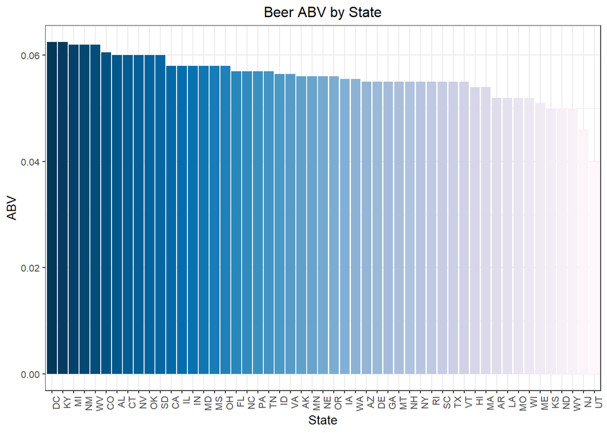

```r
#Compute median ABV and IBU by State

ABV_state <- aggregate(BandBs$ABV, list(BandBs$State), median, na.rm = TRUE) #Here we aggregate the ABV data.
names(ABV_state) <- c("State", "ABV_Pct") #rename the fields

IBU_state <- aggregate(BandBs$IBU, list(BandBs$State), median, na.rm = TRUE) #Here we aggregate the IBU data.
names(IBU_state) <- c("State", "IBUs") #This renames the fields for clarity.

IBU_state <- IBU_state[-42,] #There is one NA record to be removed, this takes it out.

getPalette = colorRampPalette(brewer.pal(9, "PuBu"))#We wanted to use a color that matched the blue header cover, and this was pretty close.

colourCountABV = length(unique(ABV_state$State)) #This assigns color gradient based on length of column.
ABV_state$State <- factor(ABV_state$State, levels = ABV_state$State[order(-ABV_state$ABV_Pct)]) #This gets the columns set up for descending order, which seemed more logical than by state abbreviation.

#The ggplot section below creates a chart to look at ABV by State.
ggplot(data = ABV_state , aes(x = ABV_state$State , y = ABV_state$ABV_Pct, fill = ABV_state$State)) + geom_bar(stat = 'identity', show.legend = FALSE) + labs(title = "Beer ABV by State", x = 'State', y = 'ABV' , fill = 'State') + theme_bw(10) + theme(axis.text.x = element_text(angle = 90,hjust = 1)) + theme(legend.title.align = 0.5) + theme(plot.title = element_text(hjust = 0.5)) + scale_fill_manual(values = rev(getPalette(colourCountABV)))
```

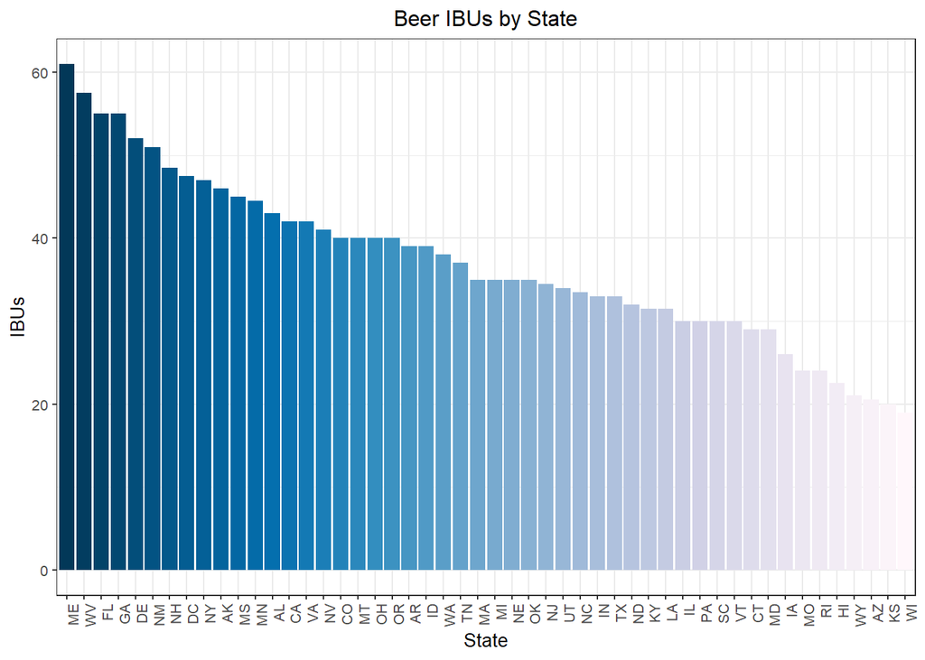

```r
colourCountIBU = length(unique(IBU_state$State)) #This assigns color gradient based on length of column.
IBU_state$State <- factor(IBU_state$State, levels = IBU_state$State[order(-IBU_state$IBUs)]) #This gets the columns set up for descending order, which seemed more logical than by state abbreviation.

#The ggplot section below creates a chart to look at IBU by State.
ggplot(data = IBU_state , aes(x = IBU_state$State , y = IBU_state$IBUs, fill = IBU_state$State)) + geom_bar(stat = "identity", show.legend = FALSE) + labs(title = "Beer IBUs by State", x = "State", y = "IBUs" , fill = 'State') + theme_bw(10) + theme(axis.text.x = element_text(angle = 90,hjust = 1)) + theme(legend.title.align = 0.5) + theme(plot.title = element_text(hjust = 0.5)) + scale_fill_manual(values = rev(getPalette(colourCountIBU)))
```

**Here is a closer look at the details for the highest values for ABV and IBU.**  
There is a tie in ABV, the District of Columbia and Kentucky both had an ABV of 0.0625. I tie is not unusual for this values, as in the chart above, where multiple states shared the same ABV value. Maine had the highest IBU value, with a beer that has 61.0 IBUs.

```
##    State ABV_Pct
## 8     DC  0.0625
## 18    KY  0.0625
```

```
##    State IBUs
## 22    ME   61
```

**We wanted to share the range of the alcohol content and bitterness**  
You can see from the boxplot that there are outliers- which can affect the analysis, but they are valid data points.

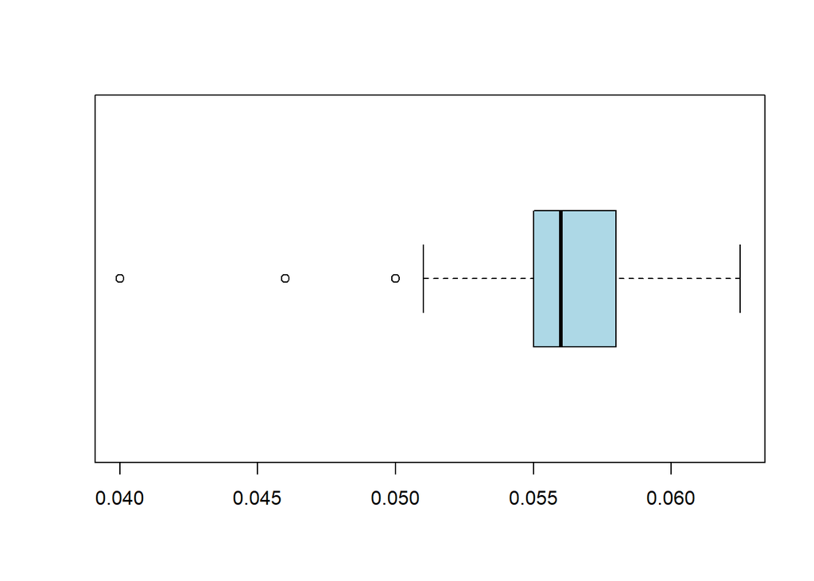

```
##    Min. 1st Qu.  Median    Mean 3rd Qu.    Max.
## 0.04000 0.05500 0.05600 0.05585 0.05800 0.06250
```

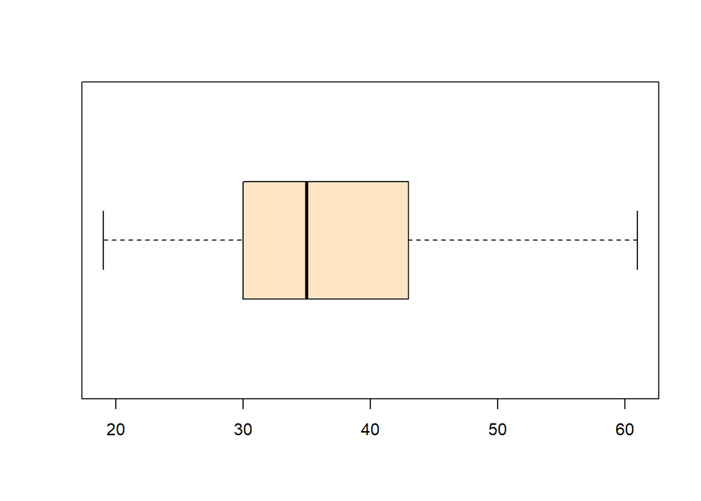

```
##    Min. 1st Qu.  Median    Mean 3rd Qu.    Max.
##   19.00   30.00   35.00   36.98   42.75   61.00
```

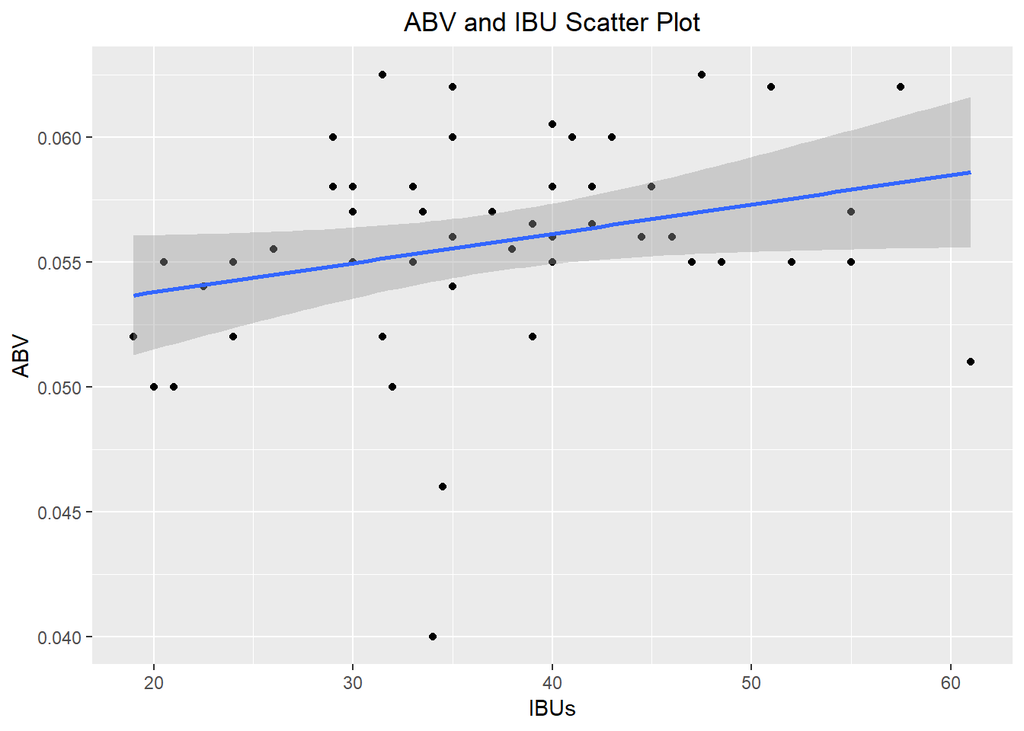

```
##
##  Pearson's product-moment correlation
##
## data:  ABV_IBU_combined$ABV_Pct and ABV_IBU_combined$IBUs
## t = 2.0371, df = 48, p-value = 0.04717
## alternative hypothesis: true correlation is not equal to 0
## 95 percent confidence interval:
##  0.004066385 0.519640151
## sample estimates:
##       cor
## 0.2820948
```

For further analysis, we recommend applying demographic information to the analysis to determine if different generational segments have preferences, and regionality of preference with the target generational segments.